# Презентация по разделу №1 дополнительного курса

Дисциплина: Архитектура компьютеров и операционные системы

Гусев Степан Андреевич

1032242444@rudn.ru

Российский университет дружбы народов

2026-05-06

# Информация

**Презентация по разделу №1 дополнительного курса**

**Автор:** Гусев Степан Андреевич

**Преподаватель:** Кулябов Дмитрий Сергеевич, д.ф.-м.н., профессор кафедры теории вероятностей и кибербезопасности

Российский университет дружбы народов

## Докладчик

- Гусев Степан Андреевич
- Студент программы “Бизнес-информатика”
- Российский университет дружбы народов им. П. Лумумбы
- 1032242444@rudn.ru
- https://github.com/stepagusev

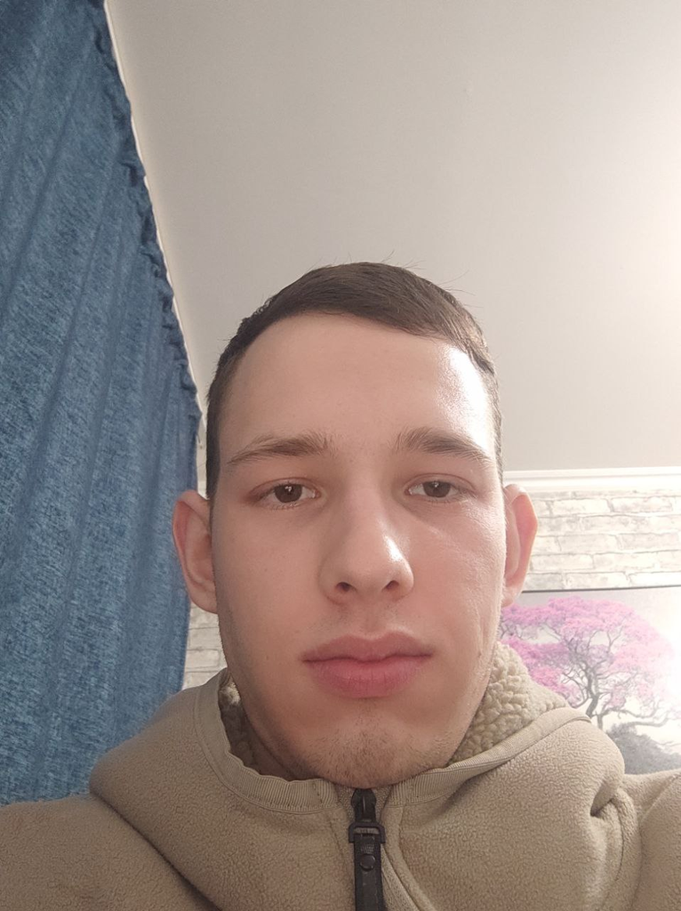

## Цель

Приобретение практических навыков работы с Linux, пройти 1-ый раздел курса “Введение в Linux” на Stepik.

## Задание

1. Пройти первый раздел курса “Введение в Linux”

# Выполнение первого раздела

## Задание 1

Формулировка задания №1 (рис. 1).

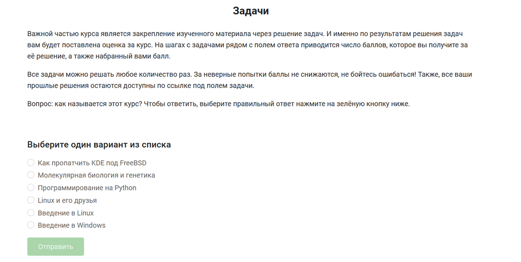

Рисунок 1: Задание №1

## Задание 1

Решение задания №1 (рис. 2).

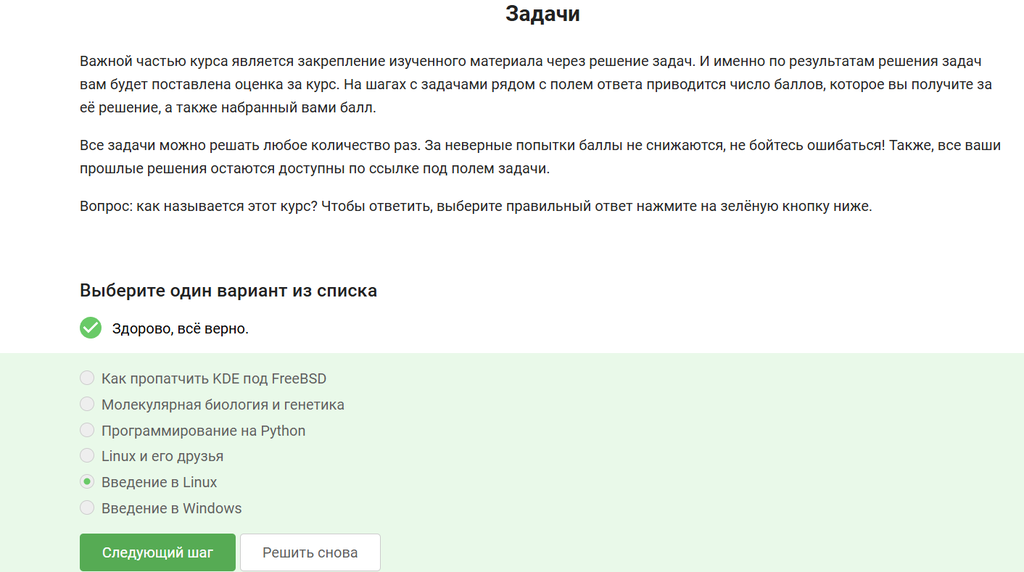

Рисунок 2: Решение №1

## Задание 2

Формулировка задания №2 (рис. 3).

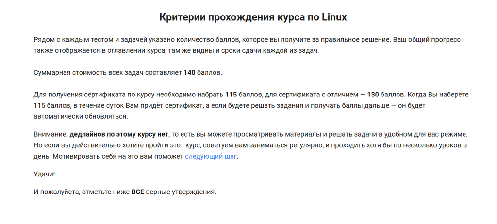

Рисунок 3: Задание №2

## Задание 2

Решение задания №2 (рис. 4).

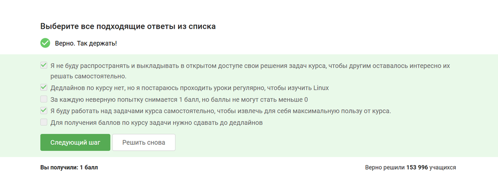

Рисунок 4: Решение №2

## Задание 3

Формулировка задания №3 (рис. 5).

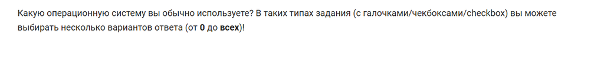

Рисунок 5: Задание №3

## Задание 3

Решение задания №3 (рис. 6).

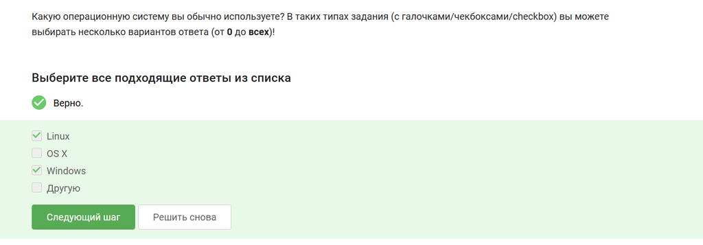

Рисунок 6: Решение №3

## Задание 4

Формулировка задания №4 (рис. 7).

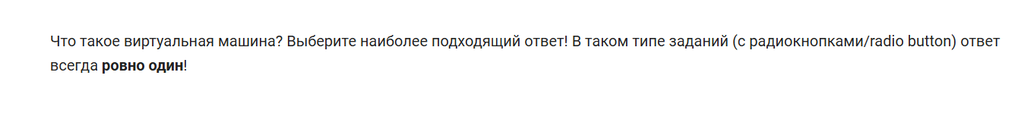

Рисунок 7: Задание №4

## Задание 4

Решение задания №4 (рис. 8).

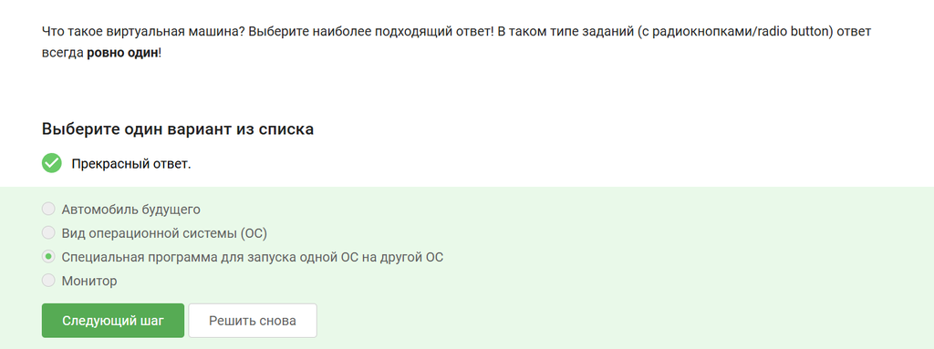

Рисунок 8: Решение №4

## Задание 5

Формулировка задания №5 (рис. 9).

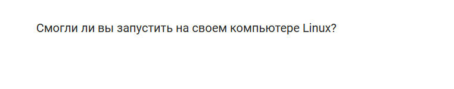

Рисунок 9: Задание №5

## Задание 5

Решение задания №5 (рис. 10).

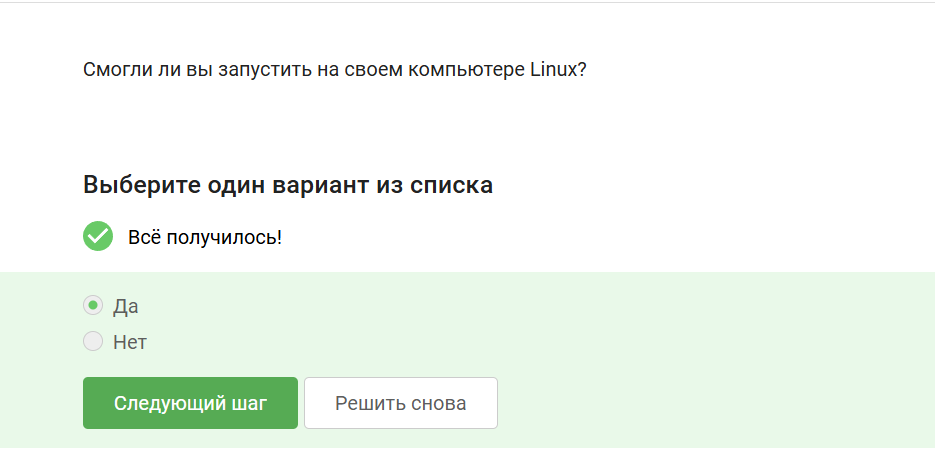

Рисунок 10: Решение №5

## Задание 6

Формулировка задания №6 (рис. 11).

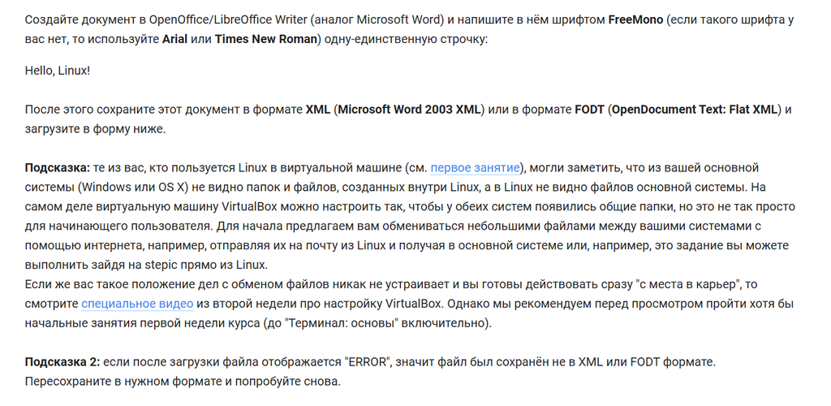

Рисунок 11: Задание №6

## Задание 6

Решение задания №6. Создал файл, ввёл нужную строку, изменил шрифт и сохранил в нужном формате (рис. 12).

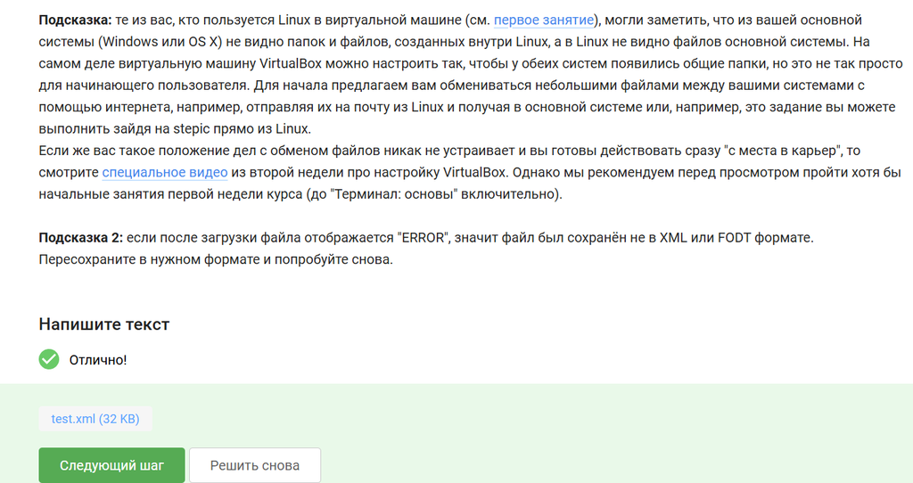

Рисунок 12: Решение №6

## Задание 7

Формулировка задания №7 (рис. 13).

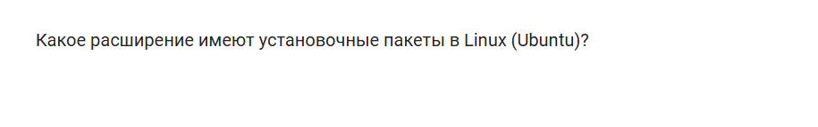

Рисунок 13: Задание №7

## Задание 7

Решение задания №7, exe - исполняемый файл для Windows, txt - текстовый файл, ubuntu - не расширение, dmg - расширение для чего-то другого (рис. 14).

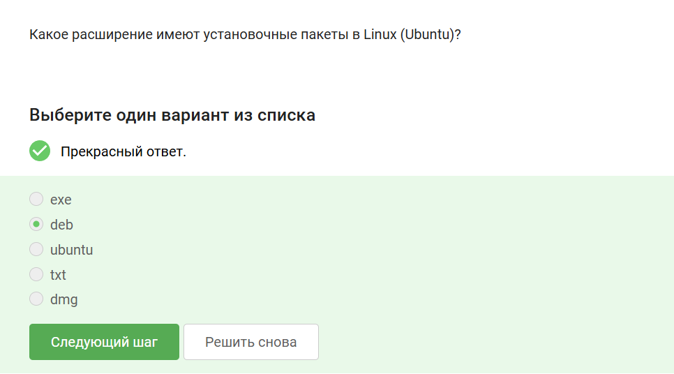

Рисунок 14: Решение №7

## Задание 8

Формулировка задания №8 (рис. 15).

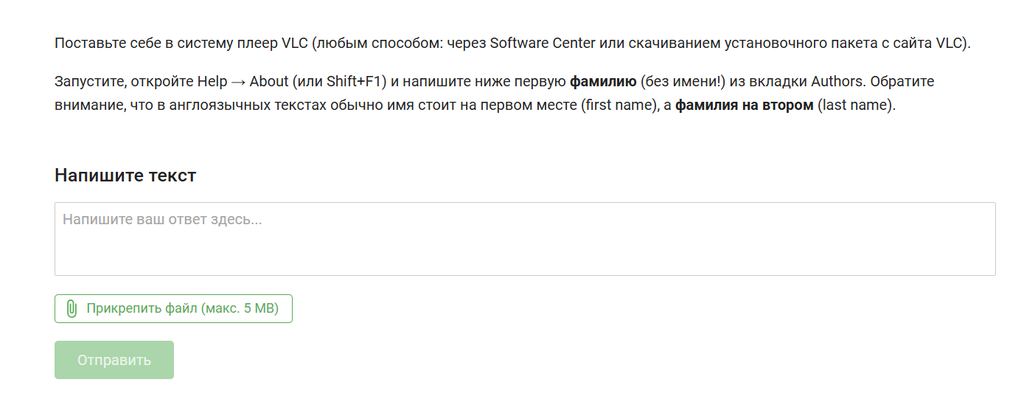

Рисунок 15: Задание №8

## Задание 8

Решение задания №8 (рис. 16).

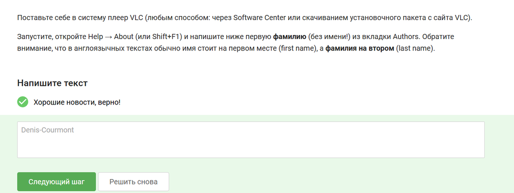

Рисунок 16: Решение №8

## Задание 9

Формулировка задания №9 (рис. 17).

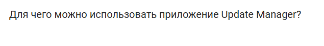

Рисунок 17: Задание №9

## Задание 9

Решение задания №9, менеджер обновлений не занимается установкой/удалением программ (рис. 18).

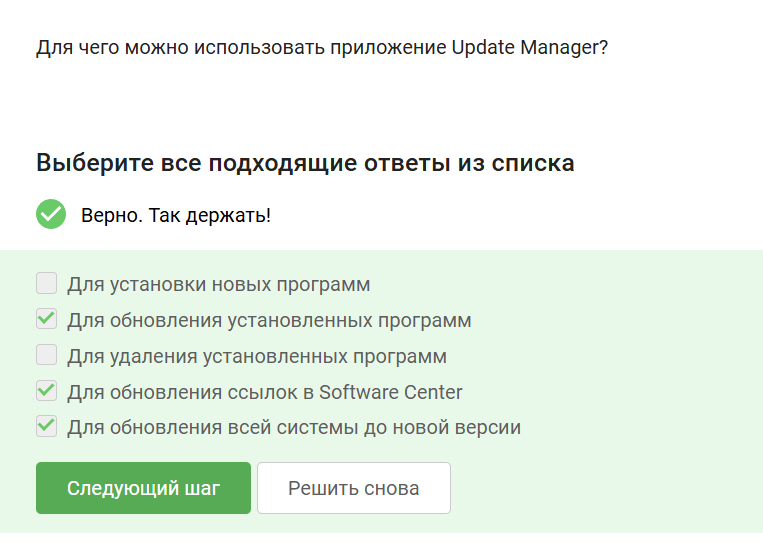

Рисунок 18: Решение №9

## Задание 10

Формулировка задания №10 (рис. 19).

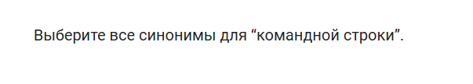

Рисунок 19: Задание №10

## Задание 10

Решение задания №10 (рис. 20).

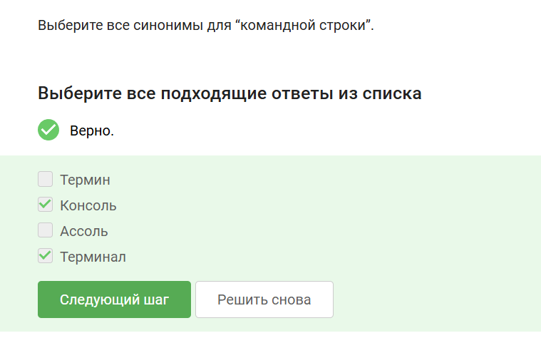

Рисунок 20: Решение №10

## Задание 11

Формулировка задания №11 (рис. 21).

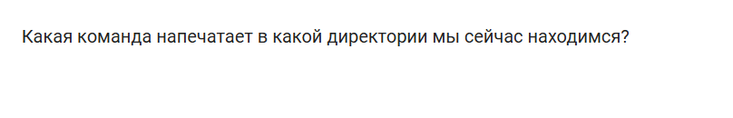

Рисунок 21: Задание №11

## Задание 11

Решение задания №11, команды в линукс регистрозависимые (рис. 22).

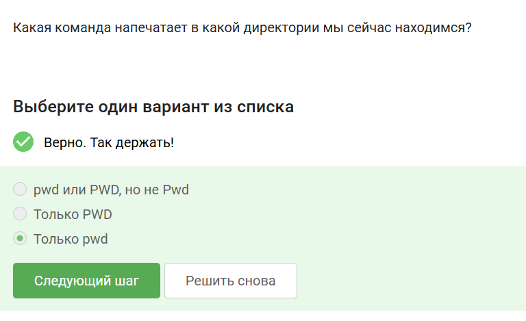

Рисунок 22: Решение №11

## Задание 12

Формулировка задания №12 (рис. 23).

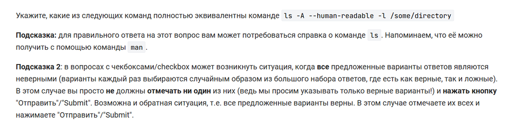

Рисунок 23: Задание №12

## Задание 12

Решение задания №12, в 1 варианте –all не равно -A, в 4 нет директории (рис. 24).

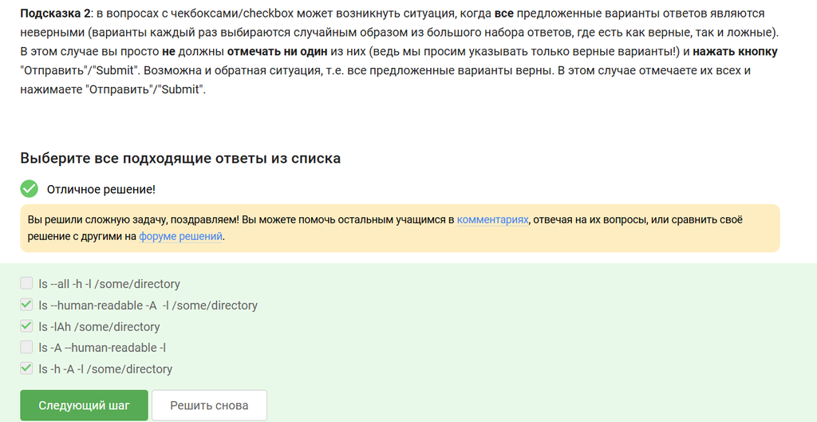

Рисунок 24: Решение №12

## Задание 13

Формулировка задания №13 (рис. 25).

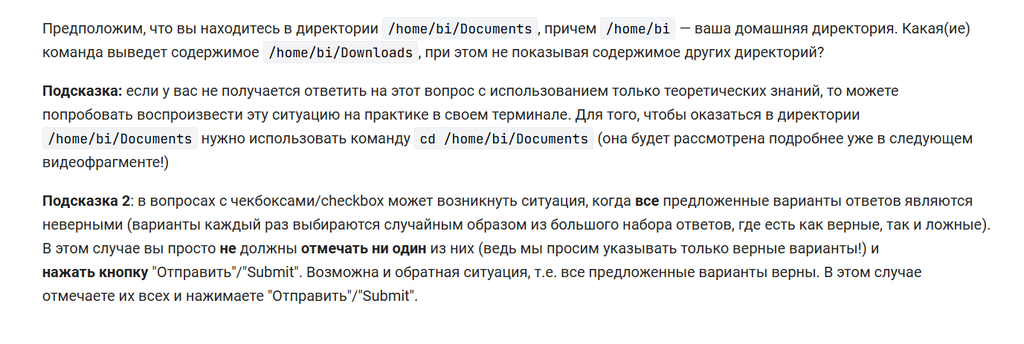

Рисунок 25: Задание №13

## Задание 13

Решение задания №13 (рис. 26).

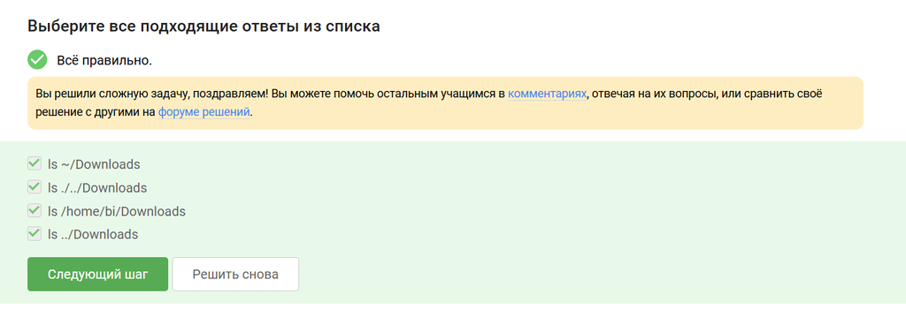

Рисунок 26: Решение №13

## Задание 14

Формулировка задания №14 (рис. 27).

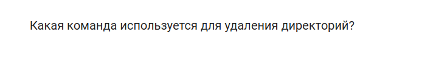

Рисунок 27: Задание №14

## Задание 14

Решение задания №14, mkdir создаёт директории, mv перемещает, rm -f удаляет принудительно (рис. 28).

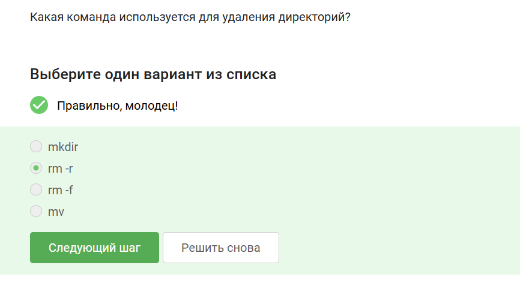

Рисунок 28: Решение №14

## Задание 15

Формулировка задания №15 (рис. 29).

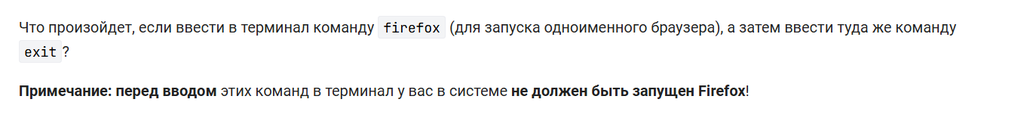

Рисунок 29: Задание №15